# Vignette for mgraph.R - a mini graph module

Detlef Groth

2022-05-07

Module documentation: mgraph.R

## Introduction

This is the vignette for the file *mgraph.R* which provides basic functionalities to work with graphs in R.

There are several good R packages like [igraph] or [network] which should be used for serious R programming. The purpose of the graph module *mgraph.R* is nore educational. The file is used in my teachings at the University of Potsdam in the courses *Machine Learning in Bioinformatics*, *Statistical Bioinformatics* and *Practical Bioinformatics*. The students should have the possibility to easily study and learn from R code and the implementations for several algorithms. The embedded documentation should as well convince the students from documenting their own code properly.

## Loading the module

The module *mgraph.R* contains functions to create certain graph types and as well methods to create graphs from data. Before you start you have usually to source the file from within your R session. All methods and variables are stored with the R environment *mgraph*. You can inspect what is available within the *mgraph* object using the ls function.

```r
source('mgraph.R')
ls() # all variables - might vary between machines
```

```
##  [1] "%>%"            "%ni%"           "argv"           "FILENAME"
##  [5] "idx"            "mgraph"         "plot.mgraph"    "sbi"
##  [9] "sbifile"        "SFLIBS"         "shelp"          "slibrary"
## [13] "summary.mgraph" "usage"
```

```r
ls(mgraph)  # module methods and variables
```

```
##  [1] "autonames"      "components"     "connect"        "d2u"
##  [5] "degree"         "FILENAME"       "graph2data"     "layout"
##  [9] "new"            "plot"           "shortest.paths" "summary"
## [13] "u2d"            "VERSION"
```

Uppercase objects are usually variables which should not be modified or private functions which should not be called from the user. Here we just output the current version of the module.

```r
print(mgraph$VERSION)
```

```
## [1] "2022-05-04"
```

## Graph generation

There is a main method for creating graphs from scratch, it is the method mgraph$new.

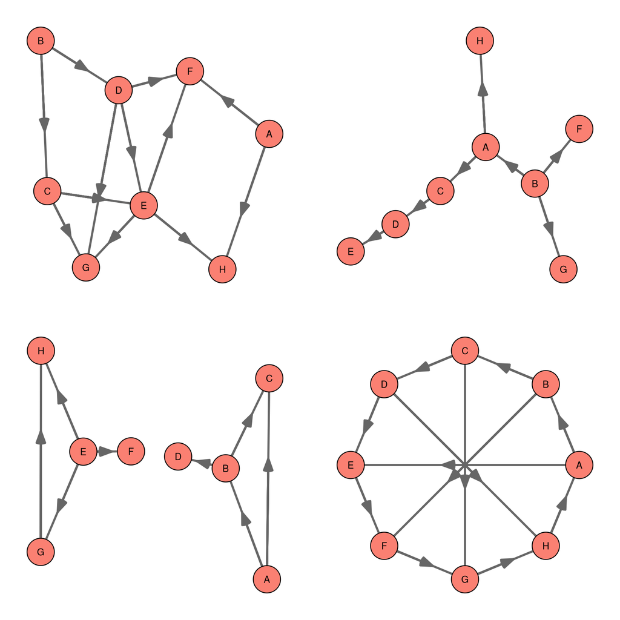

```r
set.seed(123)
par(mfrow=c(2,2),mai=rep(0.1,4))
A=mgraph$new(type="random",nodes=8,edges=12)
B=mgraph$new(type="barabasi",nodes=8,m=1)
C=mgraph$new(type="cluster",nodes=8,edges=8,k=2)
D=mgraph$new(type="regular",nodes=8,k=3)
plot(A);plot(B);plot(C);plot(D,layout="circle")
```